# Part II - (Ford GoBike System Data)

## by (Shadrack Mwangi)

## Introduction

Congested streets and slow-crawling traffic are a fact of life in many metropolitan areas, such as New York City, Los Angeles, and Chicago. Bike sharing is an innovative solution for such problems, and it works by dispersing a large fleet of publicly-available bikes throughout crowded cities for personal transport.

Implemented in 2013, Ford GoBike is the first bike-sharing system introduced in the US West Coast. Its 540 stations and 7,000 bikes sprawl across five cities in San Francisco Bay Area. A docked bike can be checked out at any station and must be returned to a station when the trip is complete. As a data fanatic, I am excited to explore, using Python, the trip data that has been collected in 2019.

## Summary of Findings

In this data visualization several features of the bike sharing data were evaluated and visualized. The gender of the riders was evaluated and most riders who used the bike sharing system in the greater San Francisco Area were male. Also, subscribers were more than customers. Older people tend to take bike rides during the day period. The age of riders decreases significantly at night and late night periods. The distance cycled was highest in the day periods and less in night periods. The distance cycled was highest in the evening and morning day periods. The longest rides are in the early morning and morning day periods. The shortest rides are in the night and late night day periods. Most of the trips were in the morning and evening hours. The least was in the late night day period. Weekends are slower for all genders of riders. Tuesdays and Thursdays are the busiest days and has the highest frequencies of rides. The noon day period is when riders spend the most time on their bike trips. Bike riders who do not share rides for the whole trip tend to cycle longer distances. Bike sharing for the whole trip was more frequent in the morning, noon, evening and night day periods, with most of the bike shares in the noon and evening day periods.

### What is the most used ride end station?

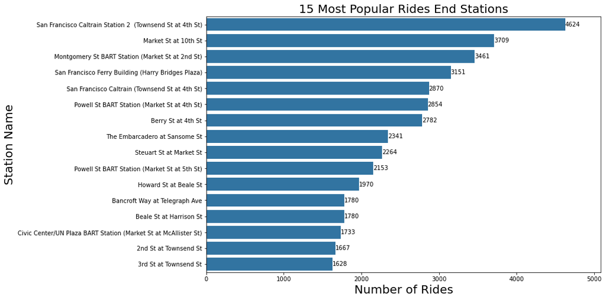

[figure not shown]

### Relationship between distance cycled and time used?

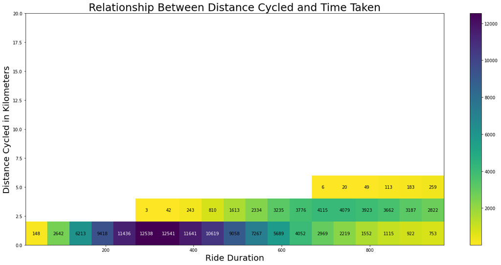

### What is the relationship between distance cyled, age, bike share for all trip, and day time periods?

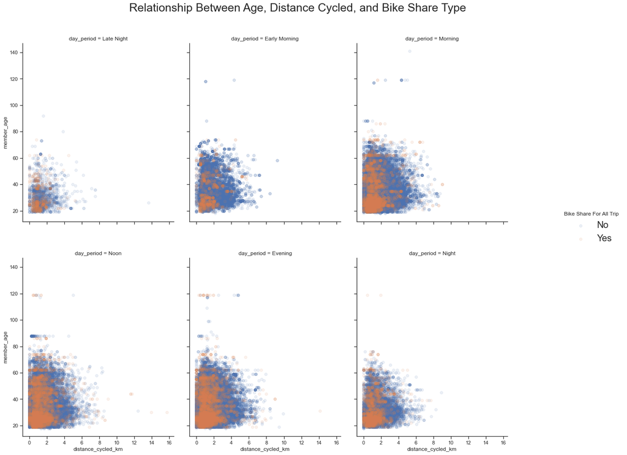

### What is the relationship between age and distance cycled on different days of the week for male subscribers?

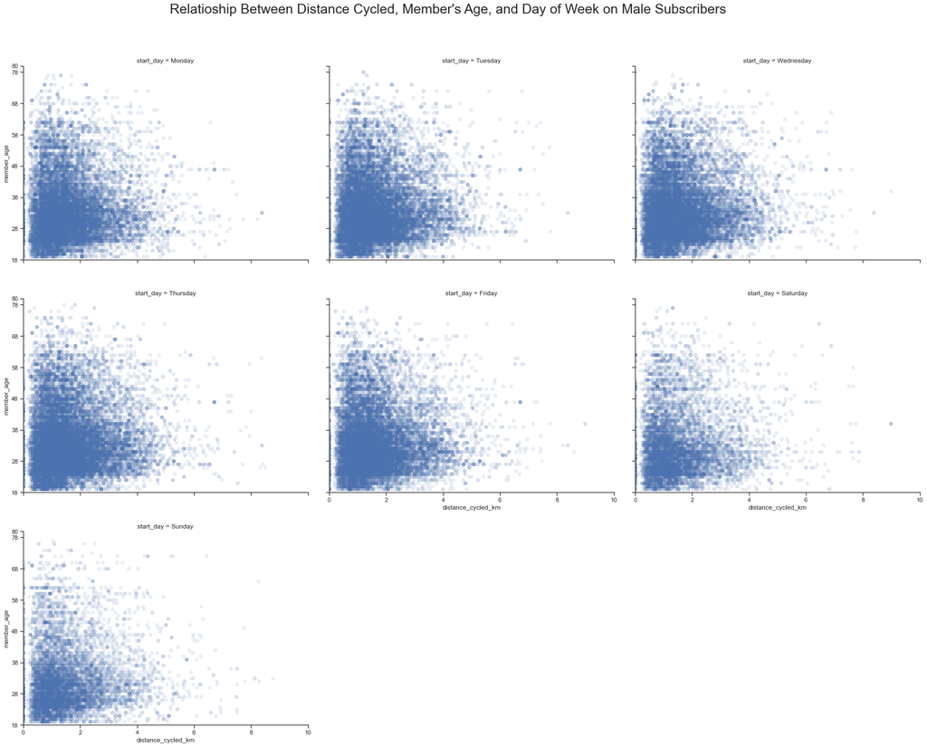